# Fauna de acuerdo a Integridad Ecológica

Queremos conocer qué animales habitan zonas íntegras y qué otros habitan zonas degradadas, para lo cual contamos con un mapa del Índice de Integridad Ecológica (IEE) y datos de fototrampeo obtenidos del proyecto SiPeCaM.

```r
library(tidyverse)
library(terra)
library(knitr)
library(ggplot2)

source("utils.R")

# Mapa de IE
r_ei <- rast('data/ie/ie_xgb_slic_2021.tif')
r_ei <- project(r_ei, "epsg:4326", method='near')
```

```
## |---------|---------|---------|---------|=========================================
```

```r
# Datos de foto trampeo
df <- read.csv('data/anotaciones/processed/anotaciones_sipecam_20241016.csv')
df <- df %>%
  mutate_at(vars(fecha_foto), as.Date, format="%Y-%m-%d") %>%
  mutate(year = year(fecha_foto))
```

De acuerdo al muestreo de SiPeCaM, se colocaron las cámaras trampa en áreas que se nombraron *cúmulos*, dentro de éstas, el terreno cuenta con las mismas características, con la diferencia que algunas zonas son íntegras y otras degradadas.

Cada renglón representa una especie observada en una foto, pudiendo haber más de un individuo de la especie en cada una. También se cuenta con las coordenadas geográficas de la cámara trampa, el cúmulo en el que fue ubicada y la fecha en la que fue tomada la foto.

| cumulo | nomenclatura_nodo | ecosistema | municipio | estado | coord_longitud | coord_latitud | fecha_foto | numero_individuos | etiqueta | anotador_id | ruta | year |
| --- | --- | --- | --- | --- | --- | --- | --- | --- | --- | --- | --- | --- |
| 95 | 1_95_1_1350 | Bosques templados | Municipio de Agua Prieta | Sonora | -108.9350 | 31.1922 | 2021-08-04 | 1 | Homo sapiens | 6 | 95/1_95_1_1350/HLPXGM09049767/2021-08-04/images_videos/304365a8cbcac0aa9a02733472d1385b_0031.JPG | 2021 |
| 95 | 1_95_1_1350 | Bosques templados | Municipio de Agua Prieta | Sonora | -108.9350 | 31.1922 | 2021-08-04 | 1 | Homo sapiens | 6 | 95/1_95_1_1350/HLPXGM09049767/2021-08-04/images_videos/a1c57200f72b9d431d062efec1cc9d78_0032.JPG | 2021 |
| 95 | 1_95_0_1348 | Bosques templados | Municipio de Agua Prieta | Sonora | -108.9520 | 31.2540 | 2021-10-12 | 1 | Equus caballus | 6 | 95/1_95_0_1348/HLPXGM09048863/2021-08-04/images_videos/b5e5b7a002263f7741c6ec2b41b804fc_0994.JPG | 2021 |
| 13 | 3_13_0_1399 | Selvas humedas | Palizada | Campeche | -91.9802 | 18.0886 | 2021-08-05 | 1 | Aves | 6 | 13/3_13_0_1399/HLPXGM09048507/2021-08-05/images_videos/a1b882d87811ce1d490d1334c34b64aa_0013.JPG | 2021 |
| 13 | 3_13_0_1399 | Selvas humedas | Palizada | Campeche | -91.9802 | 18.0886 | 2021-08-05 | 1 | Aves | 6 | 13/3_13_0_1399/HLPXGM09048507/2021-08-05/images_videos/1b16b2286f3b1f31a48c7784782ee3b4_0014.JPG | 2021 |

Primero extraemos el valor del Índice de Integridad Ecológica de acuerdo a las coordenadas.

```r
df_coord <- df %>% select(coord_longitud, coord_latitud)
df$ie_value <- terra::extract(r_ei, df_coord, method='exact')$prediction
df$ie <- ifelse(df$ie_value >= 4, 'Degradado', 'Integro')
```

Se asume que las observaciones de una especie, en un mismo sitio y en un mismo día, pertenecen a un sólo individuo. Se toma el máximo número de individuos, ya que puede haber más de uno en una sola foto.

```r
df <- df %>%
  filter(!is.na(numero_individuos)) %>%
  group_by(cumulo,
           coord_longitud, coord_latitud,
           integridad_nodo,ie,
           fecha_foto,
           etiqueta) %>%
  summarise(numero_individuos=max(numero_individuos))
```

Se suman todas las observaciones de una especie en la zona íntegra y degradada de cada cúmulo.

```r
df_counts <- df %>%
  group_by(cumulo,
           ie,
           etiqueta) %>%
  summarise(n=sum(numero_individuos,na.rm = TRUE))
df_counts <- df_counts %>%
  spread(ie,n) %>%
  replace(is.na(.), 0) %>%
  arrange(etiqueta)
```

| cumulo | etiqueta | Degradado | Integro |
| --- | --- | --- | --- |
| 31 | Conepatus leuconotus | 1 | 2 |
| 32 | Conepatus leuconotus | 1 | 2 |
| 95 | Conepatus leuconotus | 1 | 9 |
| 32 | Conepatus semistriatus | 0 | 1 |
| 92 | Conepatus semistriatus | 3 | 1 |
| 13 | Crax rubra | 0 | 6 |
| 92 | Crax rubra | 5 | 15 |
| 31 | Cricetidae | 0 | 1 |
| 92 | Cricetidae | 2 | 0 |
| 13 | Cuniculus paca | 1 | 0 |
| 92 | Cuniculus paca | 19 | 27 |
| 92 | Dasyprocta mexicana | 0 | 1 |

Se estima la media del grupo de cúmulos por cada especie, tanto en zona íntegra, como degradada. Posteriormente, se restan estos valores, obteniendo la diferencia de medias (columna *estimate*).

Para aquellas especies que tuvieron observaciones en más de un cúmulo, se corre una prueba *t* pareada, que evalúa si la diferencia de medias es diferente de cero, es decir, si existe un mayor número de observaciones, ya sea en la zona degradada o íntegra.

```r
df_test_integridad_nodo <- get_test_table(df_counts)
```

| etiqueta | estimate | statistic | p.value | parameter | conf.low | conf.high | method | alternative | n |
| --- | --- | --- | --- | --- | --- | --- | --- | --- | --- |
| Tayassu pecari | 26.0000000 | NA | NA | NA | NA | NA | NA | NA | 1 |
| Odocoileus virginianus | 17.6000000 | 1.4542971 | 0.2195447 | 4 | -16.0007217 | 51.200722 | Paired t-test | two.sided | 5 |
| Nasua narica | 11.2857143 | 2.2642394 | 0.0641734 | 6 | -0.9104999 | 23.481928 | Paired t-test | two.sided | 7 |
| Aramus guarauna | 10.0000000 | NA | NA | NA | NA | NA | NA | NA | 1 |
| Mazama temama | 10.0000000 | NA | NA | NA | NA | NA | NA | NA | 1 |
| Meleagris gallopavo | 10.0000000 | NA | NA | NA | NA | NA | NA | NA | 1 |
| Crax rubra | 8.0000000 | 4.0000000 | 0.1559583 | 1 | -17.4124095 | 33.412410 | Paired t-test | two.sided | 2 |
| Sciurus nayaritensis | 8.0000000 | NA | NA | NA | NA | NA | NA | NA | 1 |
| Ursus americanus | 8.0000000 | NA | NA | NA | NA | NA | NA | NA | 1 |
| Tinamus major | 7.0000000 | NA | NA | NA | NA | NA | NA | NA | 1 |
| Dicotyles tajacu | 6.3333333 | 1.6859774 | 0.1526109 | 5 | -3.3229954 | 15.989662 | Paired t-test | two.sided | 6 |
| Nyctanassa violacea | 6.0000000 | NA | NA | NA | NA | NA | NA | NA | 1 |
| Leopardus wiedii | 5.5000000 | 2.6170702 | 0.0792009 | 3 | -1.1881868 | 12.188187 | Paired t-test | two.sided | 4 |
| Didelphis | 5.3333333 | 0.7797923 | 0.5171427 | 2 | -24.0943510 | 34.761018 | Paired t-test | two.sided | 3 |
| Leopardus pardalis | 5.2500000 | 3.3918060 | 0.0427180 | 3 | 0.3240570 | 10.175943 | Paired t-test | two.sided | 4 |
| Tapirella bairdii | 5.0000000 | NA | NA | NA | NA | NA | NA | NA | 1 |
| Dendrortyx macroura | 4.5000000 | 3.0000000 | 0.2048328 | 1 | -14.5593071 | 23.559307 | Paired t-test | two.sided | 2 |
| Sciurus aureogaster | 4.3333333 | 2.9824045 | 0.0964375 | 2 | -1.9182761 | 10.584943 | Paired t-test | two.sided | 3 |
| Puma concolor | 4.2500000 | 2.4974807 | 0.0879017 | 3 | -1.1656160 | 9.665616 | Paired t-test | two.sided | 4 |
| Lynx rufus | 4.0000000 | 1.3333333 | 0.4096655 | 1 | -34.1186142 | 42.118614 | Paired t-test | two.sided | 2 |
| Sylvilagus | 4.0000000 | 2.0000000 | 0.2951672 | 1 | -21.4124095 | 29.412409 | Paired t-test | two.sided | 2 |
| Ortalis poliocephala | 3.6666667 | 0.7366145 | 0.5380434 | 2 | -17.7507691 | 25.084102 | Paired t-test | two.sided | 3 |
| Cuniculus paca | 3.5000000 | 0.7777778 | 0.5791668 | 1 | -53.6779213 | 60.677921 | Paired t-test | two.sided | 2 |
| Equus | 3.5000000 | 1.4000000 | 0.3948631 | 1 | -28.2655118 | 35.265512 | Paired t-test | two.sided | 2 |
| Conepatus leuconotus | 3.3333333 | 1.4285714 | 0.2893309 | 2 | -6.7061897 | 13.372856 | Paired t-test | two.sided | 3 |
| Panthera onca | 3.2500000 | 13.0000000 | 0.0009828 | 3 | 2.4543884 | 4.045612 | Paired t-test | two.sided | 4 |
| Dasypus novemcinctus | 3.1666667 | 1.6780681 | 0.1541749 | 5 | -1.6842543 | 8.017588 | Paired t-test | two.sided | 6 |
| Penelope purpurascens | 3.0000000 | 3.0000000 | 0.2048328 | 1 | -9.7062047 | 15.706205 | Paired t-test | two.sided | 2 |
| Aphelocoma wollweberi | 3.0000000 | NA | NA | NA | NA | NA | NA | NA | 1 |
| Mazama | 3.0000000 | NA | NA | NA | NA | NA | NA | NA | 1 |

[output cut: 67 more lines]

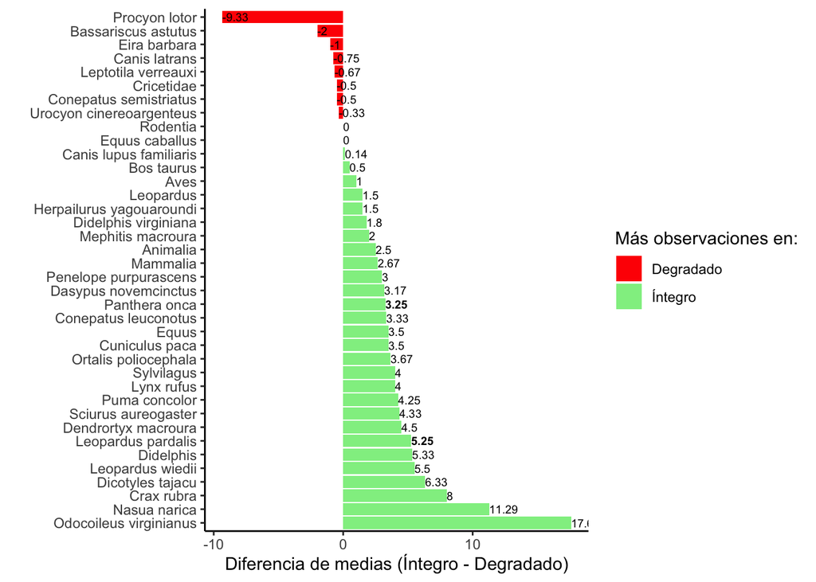